# Biostat 203B Homework 4

Due Mar 18 @ 11:59PM

Load database libraries and the tidyverse frontend:

```r
suppressPackageStartupMessages(library(tidyverse))
suppressPackageStartupMessages(library(lubridate))
suppressPackageStartupMessages(library(miceRanger))
```

## Q1. Missing data

Through the Shiny app developed in HW3, we observe abundant missing values in the MIMIC-IV ICU cohort we created. In this question, we use multiple imputation to obtain a data set without missing values.

0. Read following tutorials on the R package miceRanger for imputation: https://github.com/farrellday/miceRanger, https://cran.r-project.org/web/packages/miceRanger/vignettes/miceAlgorithm.html.

   A more thorough book treatment of the practical imputation strategies is the book [*Flexible Imputation of Missing Data*](https://stefvanbuuren.name/fimd/) by Stef van Buuren.
1. Explain the jargon MCAR, MAR, and MNAR.

**Solution**

MCAR: missing completely at random. Missingness has no relation to variables in the dataset.

MAR: missing at random. The missing data of variable Y is related to some other completely observed variable X but not related to the observed values of Y itself.

MNAR: missing not at random. Missingness is specifically related to what is missing. The missing data of variable Y is related to some other completely observed variable X and also related to the observed values of Y itself.

2. Explain in a couple of sentences how the Multiple Imputation by Chained Equations (MICE) work.

**Solution**

A variable, x, is chosen at random and the other variables are used to predict x’s values using a random forest algorithm. The next variable in line then uses the other variables (including the now full with no missing values variable x) to predict its values using a random forest algorithm. This goes on until all variables now have full non-missing data. The process does not stop though. Previously imputed values in a variable are re-imputed by running a random forest prediction algorithm using all of the other full variables. This re-imputation process is iteraterd through each variable. Once through the whole dataset, imputed variable values are re-imputated again! This re-imputation process is done several times, iterating over the full dataset, hence the term “multiple imputation”.

3. Perform a data quality check of the ICU stays data. Discard variables with substantial missingness, say >5000 `NA`s. Replace apparent data entry errors by `NA`s.

**Solution**

```r
# read rds data
icu_cohort <-
  read_rds("~/biostat-203b-2022-winter/hw3/mimiciv_shiny/icu_cohort.rds")
# parse desired variables for miceranger/prediction model
icu_cohort
```

```
##      subject_id              intime  hadm_id  stay_id
## 1      12776735 2200-07-12 00:33:00 20817525 34547665
## 2      16256226 2150-12-20 16:09:08 20013290 39289362
## 3      12974563 2138-11-13 23:30:01 29618057 32563675
## 4      14609218 2174-06-28 21:13:00 20606189 34947848
## 5      12687112 2162-05-31 18:08:45 26132667 37445058
## 6      18190935 2115-11-12 23:23:32 21137829 34338402
## 7      10404210 2161-03-03 18:30:00 22880512 30254828
## 8      12552973 2135-09-21 18:12:03 21320643 30261549
## 9      14303051 2175-11-20 01:02:00 26559537 30401486
## 10     12347959 2140-07-11 17:54:14 22779073 30503984
## 11     10716877 2187-05-27 00:13:51 21009425 30505453
## 12     13307171 2145-11-22 00:54:00 21128752 30576177
## 13     17520767 2140-10-05 00:39:00 22157359 30687338
## 14     19612002 2133-10-09 23:36:27 22839476 34559898
```

[output cut: 25572 more lines]

```r
icu_cohort1 <- icu_cohort %>%
  select(
    gender, anchor_age, insurance, language, marital_status, ethnicity,
    lab50912, lab50882, lab50960, lab50983, lab50893, lab50902, lab51221,
    lab50971, lab51301, lab50931, event220210, lab51301, lab50931, event220210,
    event223761, event220179, event220045, event220181, thirty_day_mort
  )
# examine variables for outliers  and substantial missingness
summary(icu_cohort1)
```

```
##     gender            anchor_age     insurance           language
##  Length:53065       Min.   :18.00   Length:53065       Length:53065
##  Class :character   1st Qu.:53.00   Class :character   Class :character
##  Mode  :character   Median :65.00   Mode  :character   Mode  :character
##                     Mean   :63.59
##                     3rd Qu.:77.00
##                     Max.   :91.00
##
##  marital_status      ethnicity            lab50912          lab50882
##  Length:53065       Length:53065       Min.   : 0.0000   Min.   : 2.00
##  Class :character   Class :character   1st Qu.: 0.5000   1st Qu.:18.00
##  Mode  :character   Mode  :character   Median : 0.7000   Median :21.00
##                                        Mean   : 0.8935   Mean   :20.21
##                                        3rd Qu.: 1.0000   3rd Qu.:23.00
##                                        Max.   :17.9000   Max.   :46.00
##                                        NA's   :676       NA's   :695
##     lab50960        lab50983        lab50893         lab50902
##  Min.   :0.000   Min.   : 67.0   Min.   : 0.000   Min.   : 39.00
##  1st Qu.:1.500   1st Qu.:131.0   1st Qu.: 7.400   1st Qu.: 94.00
##  Median :1.700   Median :135.0   Median : 7.900   Median : 98.00
##  Mean   :1.721   Mean   :133.9   Mean   : 7.822   Mean   : 97.29
##  3rd Qu.:1.900   3rd Qu.:137.0   3rd Qu.: 8.400   3rd Qu.:101.00
##  Max.   :9.200   Max.   :173.0   Max.   :43.000   Max.   :142.00
##  NA's   :848     NA's   :678     NA's   :1833     NA's   :685
##     lab51221       lab50971        lab51301          lab50931
##  Min.   : 0.0   Min.   :0.700   Min.   :  0.000   Min.   :   0.0
##  1st Qu.:22.6   1st Qu.:3.200   1st Qu.:  4.500   1st Qu.:  75.0
##  Median :26.8   Median :3.500   Median :  6.200   Median :  87.0
##  Mean   :27.6   Mean   :3.495   Mean   :  6.835   Mean   :  89.5
##  3rd Qu.:32.1   3rd Qu.:3.800   3rd Qu.:  8.200   3rd Qu.:  99.0
##  Max.   :61.0   Max.   :9.400   Max.   :471.700   Max.   :1091.0
##  NA's   :693    NA's   :678     NA's   :714       NA's   :702
##   event220210      event223761      event220179      event220045
##  Min.   : 0.000   Min.   :-99.90   Min.   :-69.00   Min.   :-241395.00
##  1st Qu.: 7.000   1st Qu.: 96.70   1st Qu.: 79.00   1st Qu.:     54.00
##  Median :10.000   Median : 97.40   Median : 90.00   Median :     62.00
##  Mean   : 9.401   Mean   : 96.52   Mean   : 89.33   Mean   :     57.07
##  3rd Qu.:12.000   3rd Qu.: 97.80   3rd Qu.:100.00   3rd Qu.:     72.00
##  Max.   :37.000   Max.   :104.00   Max.   :246.00   Max.   :    150.00
##  NA's   :37       NA's   :819      NA's   :512      NA's   :1
##   event220181        thirty_day_mort
##  Min.   :-22767.00   Length:53065
##  1st Qu.:    48.00   Class :character
##  Median :    57.00   Mode  :character
##  Mean   :    56.14
##  3rd Qu.:    65.00
##  Max.   :   162.00
##  NA's   :533
```

```r
colSums(is.na(icu_cohort1))
```

```
##          gender      anchor_age       insurance        language  marital_status
##               0               0               0               0            4617
##       ethnicity        lab50912        lab50882        lab50960        lab50983
##               0             676             695             848             678
##        lab50893        lab50902        lab51221        lab50971        lab51301
##            1833             685             693             678             714
##        lab50931     event220210     event223761     event220179     event220045
##             702              37             819             512               1
##     event220181 thirty_day_mort
##             533               0
```

```r
# replace chart and lab events < 0 with NA
icu_cohort2 <- icu_cohort1 %>%
  mutate(
    event223761 = replace(event223761, event223761 < 0, NA),
    event220179 = replace(event220179, event220179 < 0, NA),
    event220045 = replace(event220045, event220045 < 0, NA),
    event220181 = replace(event220181, event220181 < 0, NA)
  )
```

4. Impute missing values by `miceRanger` (request $m=3$ data sets). This step is computational intensive. Make sure to save the imputation results as a file. Hint: Setting `max.depth=10` in the `miceRanger` function may cut some computing time.

**Solution**

```r
require(miceRanger)
set.seed(1)
# impute values using miceRanger
seqTime <- system.time(
  icu_cohort_imputed <- miceRanger(
      icu_cohort2
    , m = 3
    , returnModels = FALSE
    , verbose = FALSE
    , max.depth = 10

  )
)
icu_cohort_imputed %>%
    write_rds("icu_cohort_imputed.rds")
```

5. Make imputation diagnostic plots and explain what they mean.

**Solution**

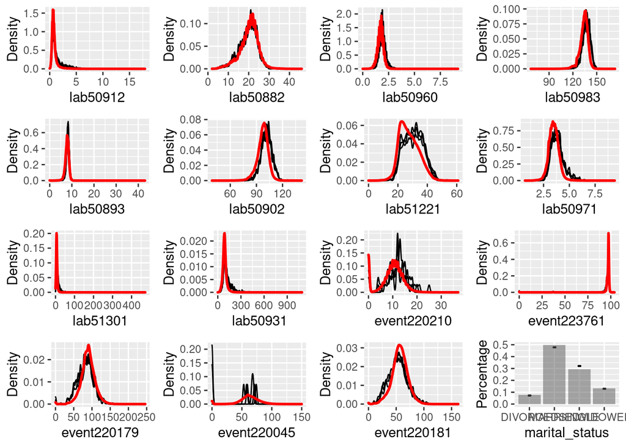

```r
icu_cohort_imputed <- read_rds("icu_cohort_imputed.rds")
plotDistributions(icu_cohort_imputed)
```

These models plot the imputed distributions compared to the original distribution for each variable. The red line is the density of the original, nonmissing data. The smaller, black lines are the density of the imputed values in each of the datasets. For those variables where the lines do not match up, it may tell us that our data was not MCAR.

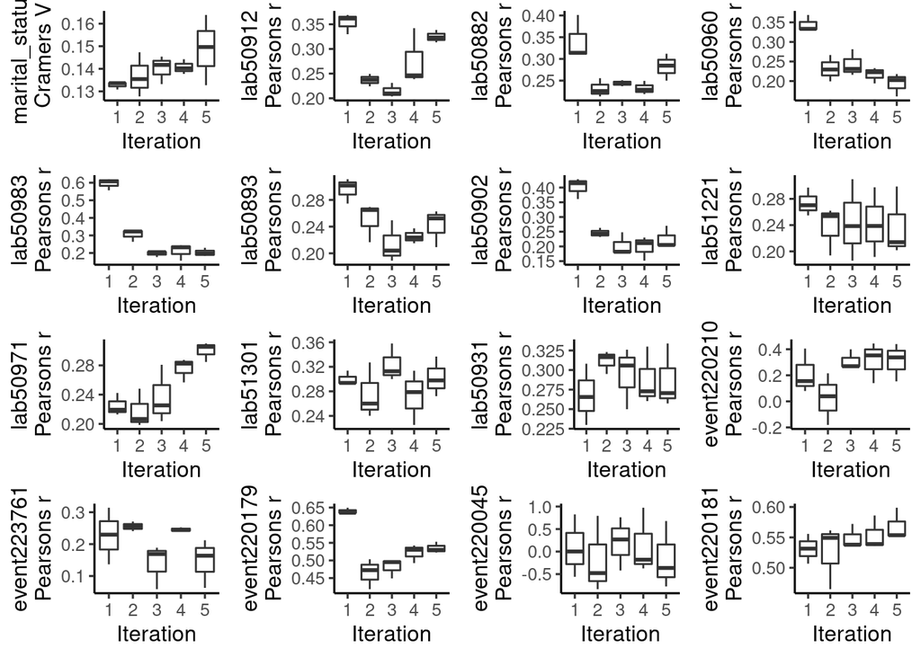

```r
plotCorrelations(icu_cohort_imputed)
```

These plotCorrelations models shows us a boxplot of the correlations between imputed values in every combination of datasets, at each iteration. This helps us know how our values between datasets converged over the iterations.

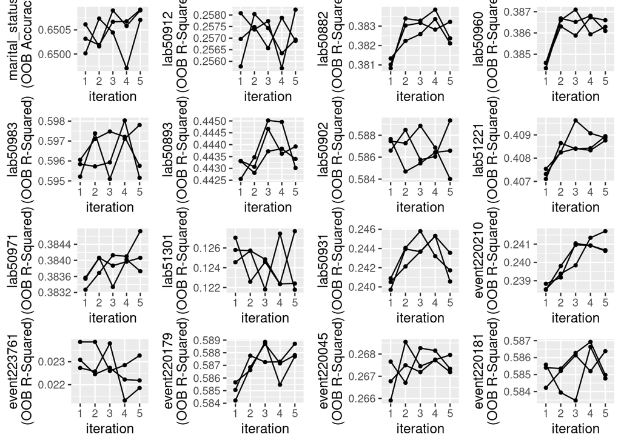

```r
plotModelError(icu_cohort_imputed)
```

Each of these models return the OOB accuracy for classification and r-squared for regression. We can see how these converged as the iterations progress.

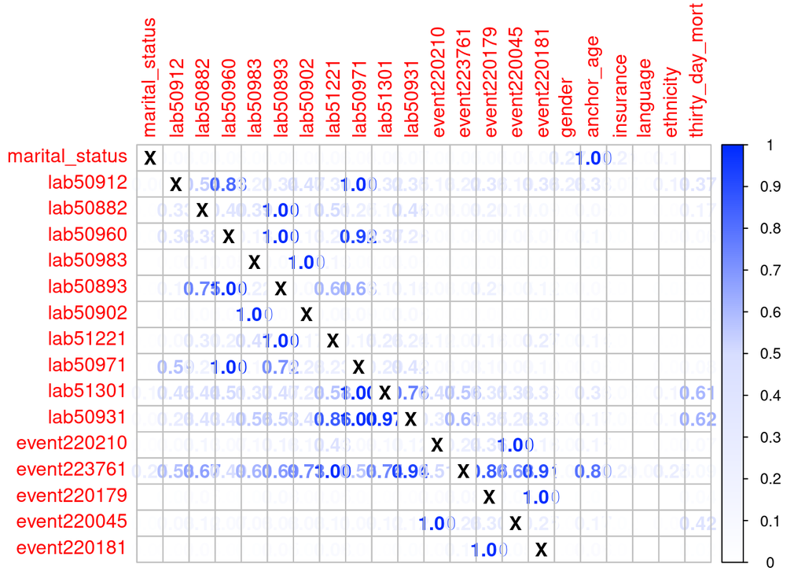

```r
plotVarImportance(icu_cohort_imputed)
```

These plots show the variable importance for each imputed variable. The top axis contains the variable that was used to impute the variable on the left axis.

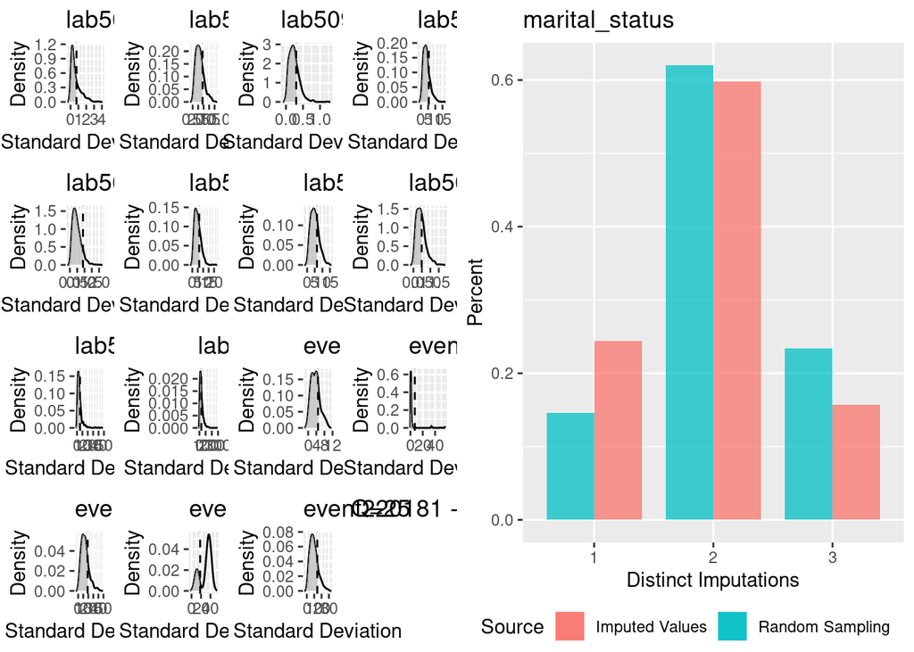

```r
plotImputationVariance(icu_cohort_imputed)
```

The imputation variance plots show how “certain” we were of our imputations. This gives us a feel for the variance experienced for each imputed value between the datasets.

6. Choose one of the imputed data sets to be used in Q2. This is **not** a good idea to use just one imputed data set or to average multiple imputed data sets. Explain in a couple of sentences what the correct Multiple Imputation strategy is.

**Solution**

The correct multiple imputation strategy is to conduct analyses on each of the imputed datasets separately and then pool all of the results.

## Q2. Predicting 30-day mortality

Develop at least two analytic approaches for predicting the 30-day mortality of patients admitted to ICU using demographic information (gender, age, marital status, ethnicity), first lab measurements during ICU stay, and first vital measurements during ICU stay. For example, you can use (1) logistic regression (`glm()` function in base R or keras), (2) logistic regression with lasso penalty (glmnet or keras package), (3) random forest (randomForest package), or (4) neural network (keras package).

1. Partition data into 80% training set and 20% test set. Stratify partitioning according the 30-day mortality status.

```r
# extract a dataset from the three imputed datasets
d <- completeData(icu_cohort_imputed)
df <- d$Dataset_1
# partition data into training and test
# load caret library
library(caret)
# set seed
set.seed(3456)
# create index for training data
train_index <- caret::createDataPartition(df$thirty_day_mort, p = .8,
                                          list = F,
                                          times = 1)
# create train and test dfs from indices
df_train <- df[train_index,]
df_test  <- df[-train_index,]
```

2. Train the models using the training set.

**Logistic regression**

```r
# change thirty day mortality entries to binary instead of string
df_train_logreg <- df_train %>%
  mutate(
    thirty_day_mort = ifelse(thirty_day_mort == "Yes", 1, 0)
  )
df_test_logreg <- df_test %>%
  mutate(
    thirty_day_mort = ifelse(thirty_day_mort == "Yes", 1, 0)
  )
# log reg model
logreg <- glm(thirty_day_mort ~ . -thirty_day_mort,
                data = df_train_logreg, family = binomial())
# display results
summary(logreg)
```

```
##
## Call:
## glm(formula = thirty_day_mort ~ . - thirty_day_mort, family = binomial(),
##     data = df_train_logreg)
##
## Deviance Residuals:
##     Min       1Q   Median       3Q      Max
## -5.8806  -0.3630  -0.2349  -0.1419   4.1491
##
## Coefficients:
##                                   Estimate Std. Error z value Pr(>|z|)
## (Intercept)                     -8.1139706  0.9686288  -8.377  < 2e-16 ***
## genderM                         -0.1925654  0.0435210  -4.425 9.66e-06 ***
## anchor_age                       0.0193809  0.0016187  11.973  < 2e-16 ***
## insuranceMedicare               -0.2834908  0.0949206  -2.987  0.00282 **
## insuranceOther                  -0.2759307  0.0908913  -3.036  0.00240 **
## languageENGLISH                  0.0745495  0.0733658   1.016  0.30957
## marital_statusMARRIED            0.0317881  0.0812915   0.391  0.69577
## marital_statusSINGLE             0.1049021  0.0861823   1.217  0.22352
## marital_statusWIDOWED            0.1297359  0.0920506   1.409  0.15872
## ethnicityASIAN                   1.7207825  0.7838568   2.195  0.02814 *
## ethnicityBLACK/AFRICAN AMERICAN  1.5222661  0.7777335   1.957  0.05031 .
## ethnicityHISPANIC/LATINO         1.5878067  0.7855521   2.021  0.04325 *
## ethnicityOTHER                   1.4970253  0.7803831   1.918  0.05507 .
## ethnicityUNABLE TO OBTAIN        2.1096703  0.7877579   2.678  0.00740 **
## ethnicityUNKNOWN                 2.1622099  0.7755597   2.788  0.00530 **
## ethnicityWHITE                   1.4842391  0.7744778   1.916  0.05531 .
## lab50912                         0.3764521  0.0226986  16.585  < 2e-16 ***
## lab50882                        -0.1101122  0.0052167 -21.108  < 2e-16 ***
## lab50960                         0.8413224  0.0818895  10.274  < 2e-16 ***
## lab50983                         0.0153964  0.0061639   2.498  0.01250 *
## lab50893                        -0.2505251  0.0266967  -9.384  < 2e-16 ***
## lab50902                         0.0452996  0.0050188   9.026  < 2e-16 ***
## lab51221                        -0.0027736  0.0038442  -0.722  0.47060
## lab50971                         0.3056601  0.0469984   6.504 7.84e-11 ***
## lab51301                         0.1434656  0.0049251  29.129  < 2e-16 ***
## lab50931                         0.0205652  0.0007238  28.415  < 2e-16 ***
## event220210                     -0.0504351  0.0043468 -11.603  < 2e-16 ***
## event223761                     -0.0062797  0.0021303  -2.948  0.00320 **
## event220179                     -0.0271096  0.0015565 -17.417  < 2e-16 ***
## event220045                     -0.0253930  0.0010001 -25.392  < 2e-16 ***
## event220181                     -0.0058847  0.0022012  -2.673  0.00751 **
## ---
## Signif. codes:  0 '***' 0.001 '**' 0.01 '*' 0.05 '.' 0.1 ' ' 1
##
## (Dispersion parameter for binomial family taken to be 1)
##
##     Null deviance: 28050  on 42451  degrees of freedom
## Residual deviance: 17865  on 42421  degrees of freedom
## AIC: 17927
##
## Number of Fisher Scoring iterations: 6
```

**Logistic regression with lasso penalty**

```r
#load required library
library(glmnet)
```

```r
#create covariate matrix and predictor variable as x and y
x <- model.matrix(thirty_day_mort ~ ., df_train)
y <- df_train$thirty_day_mort
#find optimal value of lambda
#family= binomial => logistic regression, alpha=1 => lasso
cv.out <- cv.glmnet(x, y, alpha=1, family = "binomial", type.measure = "auc" )
#plot result
#plot(cv.out)
#min value of lambda
lambda_min <- cv.out$lambda.min
#best value of lambda
lambda_1se <- cv.out$lambda.1se
#regression coefficients from the model
coef(cv.out, s = lambda_1se)
```

```
## 32 x 1 sparse Matrix of class "dgCMatrix"
##                                           s1
## (Intercept)                     -4.163590547
## (Intercept)                      .
## genderM                          .
## anchor_age                       0.010243517
## insuranceMedicare                .
## insuranceOther                   .
## languageENGLISH                  .
## marital_statusMARRIED            .
## marital_statusSINGLE             .
## marital_statusWIDOWED            .
## ethnicityASIAN                   .
## ethnicityBLACK/AFRICAN AMERICAN  .
## ethnicityHISPANIC/LATINO         .
## ethnicityOTHER                   .
## ethnicityUNABLE TO OBTAIN        .
## ethnicityUNKNOWN                 0.355953304
## ethnicityWHITE                   .
## lab50912                         0.321261805
## lab50882                        -0.082999662
## lab50960                         0.232215124
## lab50983                         .
## lab50893                        -0.009048732
## lab50902                         0.032481665
## lab51221                         .
## lab50971                         0.065834412
## lab51301                         0.112616324
## lab50931                         0.014676753
## event220210                     -0.022393995
## event223761                      .
## event220179                     -0.022047122
## event220045                     -0.021994810
## event220181                     -0.001545786
```

3. Compare model prediction performance on the test set.

**Logistic regression**

```r
# model
logreg_test <- glm(thirty_day_mort ~ . -thirty_day_mort,
                data = df_test_logreg, family = binomial())
# predicted values
log_prob <- predict(logreg_test, type = "response")
#translate probabilities to predictions
log_predict <- ifelse(log_prob > .5, 1, 0)
#confusion matrix
table(predicted = log_predict, observed = df_test_logreg$thirty_day_mort)
```

```
##          observed
## predicted    0    1
##         0 9413  637
##         1  113  450
```

```r
# accuracy
cat("Test Accuracy:", mean(log_predict == df_test_logreg$thirty_day_mort))
```

```
## Test Accuracy: 0.929332
```

**Logistic regression with lasso penalty test results**

```r
#get test data
x_test <- model.matrix(df_test$thirty_day_mort ~ ., df_test)
#predict thirty day mortality
lasso_prob <- predict(cv.out, newx = x_test, s = lambda_1se, type = "response")
#translate probabilities to predictions
lasso_predict <- ifelse(lasso_prob > .5, "Yes", "No")
#confusion matrix
table(predicted = lasso_predict, observed = df_test$thirty_day_mort)
```

```
##          observed
## predicted   No  Yes
##       No  9478  762
##       Yes   48  325
```

```r
# accuracy
cat("Test Accuracy:", mean(lasso_predict == df_test$thirty_day_mort))
```

```
## Test Accuracy: 0.9236785
```